# Machine Learning Project

## Prediction of barbell lifts

by Bruno Berrehuel ([LinkedIn](https://fr.linkedin.com/in/brunoberrehuel))

# Executive overview

Using devices such as Jawbone Up, Nike FuelBand, and Fitbit it is now possible to collect a large amount of data about personal activity relatively inexpensively. One thing that people regularly do is quantify how much of a particular activity they do, but they rarely quantify how well they do it. This report predicts the manner in which people did the exercises, based on data from accelerometers on the belt, forearm, arm, and dumbell.  
Despite that all variables with NAs have been removed, the models accuracies are very good, as shown in figure below. In this case, variables with NA aren’t necessary to fit a good prediction model.  
Further fine tuning could be done on the model, but this will not be seen in this report.  
*A good model should have good accuracy for few computation time. So I recommand using the **Bagged Tree model** as shown in figure below. It is possible to predict and survey, not only **if** people do exercices, or **how many** exercises they do, but most of it **how well** they do them.*

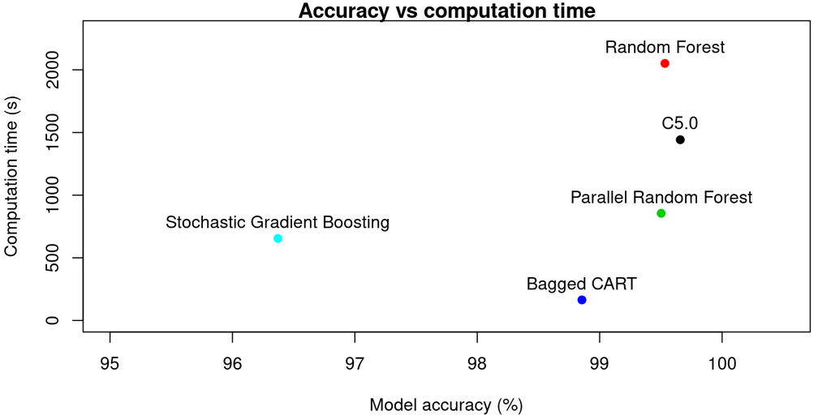

# Introduction

To predict how well people do exercices, six candidates were asked to perform barbell lifts correctly and incorrectly in 5 different ways. Results in the datasets are classified in 5 classes, according to how the exercises are done :

- Class A : exactly according to the specification
- Class B : throwing the elbows to the front
- Class C : lifting the dumbbell only halfway
- Class D : lowering the dumbbell only halfway
- Class E : throwing the hips to the front.

Source : http://groupware.les.inf.puc-rio.br/har

# Dealing with datas

## Exploratory Analysis}

There are *160 potentials predictors*, for *19622 observations*.  
After a look on the structures of the data, the following columns can be removed because they have no added value for predictive model purpose : V1, user_name, timestamps and windows columns.

There are still 153 potentials predictors, and it seems to have several NAs in the dataset, and they have to be managed.

## Dealing with NAs

In this dataset, there is no classified case without NA’s. So it is necessary to view the distribution of the NAs in the predictors, here the columns of the dataset, and find a solution to deal with them.

As seen on figure and the table below, there are only two cases for predictors with NA :

- there is no NA in the predictor
- there are a lot of NA in the predictor, more than 97.9%.

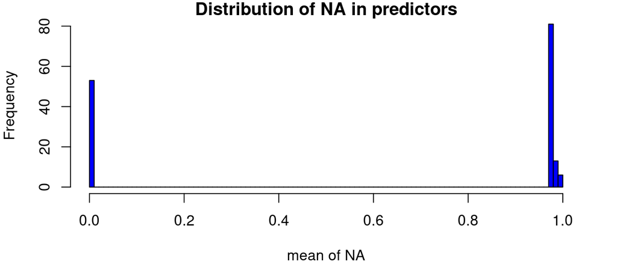

Mean of NAs in predictors with NAs

| min | mean | max | sd |
| --- | --- | --- | --- |
| 0.979 | 0.981 | 1 | 0.005 |

*Predictors with NAs can be safely removed in order to reduce noise without available informations.*

There are now *53 predictors*, which will be a little easier to manage with fitting model.

# Fitting a predictive model

The model analysis will be :

1. test variety of models on a small sample of the dataset, with the default parameters. The train will be checked by cross-validation of 10 folds, repeated 3 times, and the distribution of the accuracy, with statistique test, will be reviewed.
2. select the bests 5 of them for accuracy, then train and test them with cross-validation on the complete dataset, under the same testing conditions.
3. finally choose the best one. Further analysis could be done to tune the selected model in order to increase performance in accuracy and computation time, but it’s not the goal of this report.

Source : http://machinelearningmastery.com/evaluate-machine-learning-algorithms-with-r/

## Global quick review

The Machine Learning algorithms are choosen to represent a good mix of algorithms. For this classification case, the 21 models chosen are listed in table below.

| model |
| --- |
| Bagged Flexible Discriminant Analysis |
| C5.0 |
| Stacked AutoEncoder Deep Neural Network |
| Multivariate Adaptive Regression Spline |
| Stochastic Gradient Boosting |
| Generalized Partial Least Squares |
| High Dimensional Discriminant Analysis |
| Linear Discriminant Analysis |
| k-Nearest Neighbors |
| Mixture Discriminant Analysis |
| Naive Bayes |
| Neural Network |
| Parallel Random Forest |
| Nearest Shrunken Centroids |
| Penalized Discriminant Analysis |
| Random Forest |
| CART |
| Stabilized Nearest Neighbor Classifier |
| Support Vector Machines with Linear Kernel |
| Support Vector Machines with Radial Basis Function Kernel |
| Bagged CART |

As seen on figure below, the five bests models for accuracy are :

| Best Five Models |
| --- |
| C5.0 |
| Random Forest |
| Parallel Random Forest |
| Stochastic Gradient Boosting |
| Bagged CART |

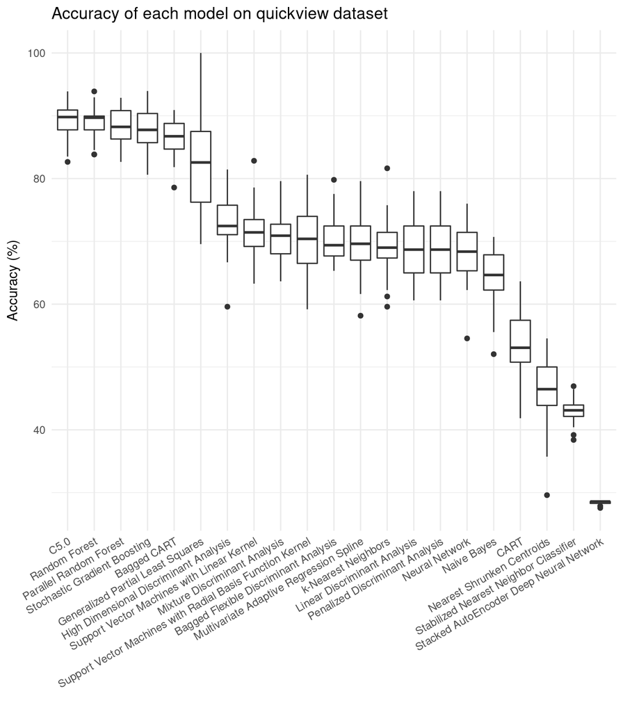

The models have pretty good accuracy, from 89.1% to 86.4%. The *Bagging CART model* is especially interesting because of its small computation time, 9 seconds, in comparaison of the 77 seconds for the C5.0 model (Computations times are calculated with computation on parallel work on 6 cores i7 cpu).

|  | min | max |
| --- | --- | --- |
| **C5.0** | 88.1 | 90.2 |
| **Random Forest** | 87.9 | 89.8 |
| **Parallel Random Forest** | 87.1 | 89.4 |
| **Stochastic Gradient Boosting** | 86.6 | 88.9 |
| **Bagged CART** | 85.3 | 87.5 |

## Best 5 models study

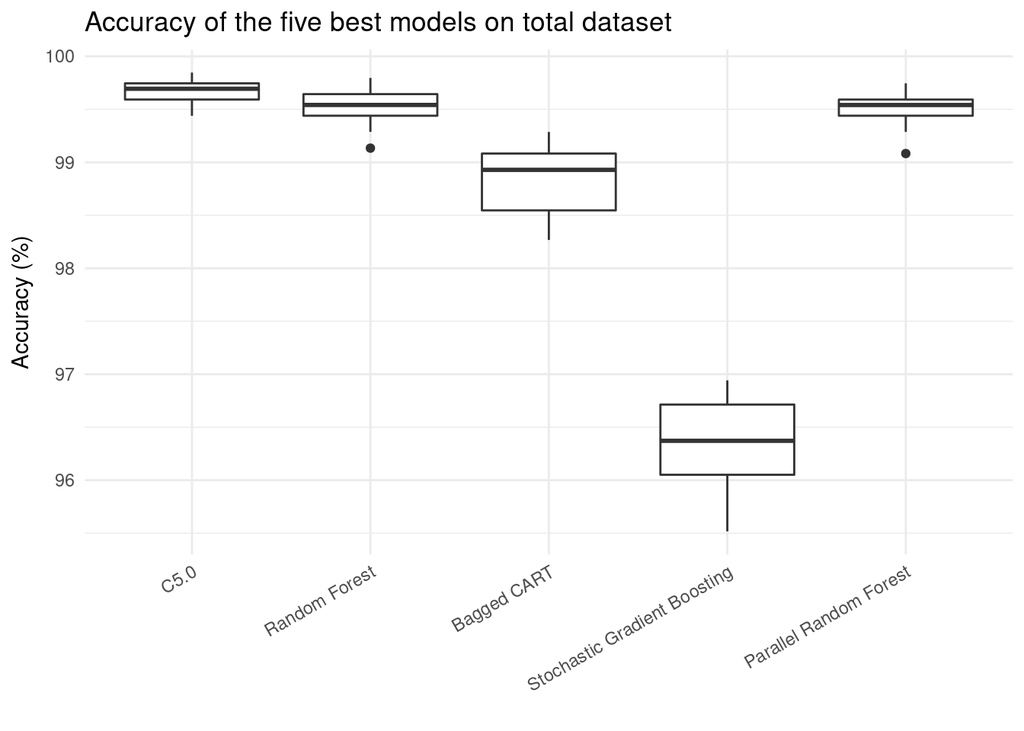

Accuracy and computation time for the 5 bests models

|  | Accuracy | Time |
| --- | --- | --- |
| **C5.0** | 99.66 | 1442 |
| **Random Forest** | 99.53 | 2052 |
| **Parallel Random Forest** | 99.5 | 855 |
| **Bagged CART** | 98.86 | 164 |
| **Stochastic Gradient Boosting** | 96.37 | 655 |

The most important result is that the accuracies are very, very good, around 99%, and with small variations around the mean, as seen with the boxplots on the figure upward.

Note the small decrease in performance of the Stochastic Gradient Boosting model, which is now worse than the Bagging CART model. The computations times have a very broad set, from 1 times 13 depending on the model considered.

# And the winner is…

# Acknowledgments

Special thanks to [Machine Learning Mastery](http://machinelearningmastery.com) for sharing methods and tricks on data science, especially the method used in this report.

# Code

All the code used in this report is written below.

## Load Datas

```r
library(doMC)
registerDoMC(cores=6) # parallel computation

library(data.table)
library(xtable)

# Downloading files if they don't already exist
if(!file.exists("datas/trainDatas.csv")){
    download.file("https://d396qusza40orc.cloudfront.net/
                  predmachlearn/pml-training.csv", "datas/trainDatas.csv")}
if(!file.exists("datas/testDatas.csv")){
    download.file("https://d396qusza40orc.cloudfront.net/
                  predmachlearn/pml-testing.csv", "datas/testDatas.csv")}

datas <- fread("datas/trainDatas.csv", na.strings=c("NA","","#DIV/0!"))
quizz <- fread("datas/testDatas.csv", na.strings=c("NA","","#DIV/0!"))
```

## Simplify dataset and deal with NAs

### NA distribution

```r
# remove unwanted columns
clean1 <- subset(datas, select = c(-1:-7))
# look at NA distribution in predictors
colNA <- apply(clean1, 2, is.na)
meanNA <- apply(colNA, 2, mean)
index <- 1:ncol(colNA)
meanNA <- cbind(meanNA,index)
meanNA <- data.frame(meanNA)
```

```r
# Plot the distribution
par(mar=c(4,4,1,2))
hist(meanNA$meanNA, breaks=75, col="blue",
     xlab="mean of NA", main="Distribution of NA in predictors")
```

### NA mean

```r
# Calculate mean of NA in predictors
naSums <- colSums(is.na(clean1))
dirty <- subset(clean1, select = (naSums!=0))
dirtyColNA <- apply(dirty, 2, is.na)
dirtyMeanNA <- apply(dirtyColNA, 2, mean)
resultsNA <- data.frame(mean=mean(dirtyMeanNA), sd=sd(dirtyMeanNA))
sumNA <- summary(dirtyMeanNA)
mini <- round(min(dirtyMeanNA),4)
maxi <- round(max(dirtyMeanNA),4)
moy <- round(mean(dirtyMeanNA),4)
sdev <- round(sd(dirtyMeanNA),4)
sumNA <- data.frame(min=mini, mean=moy, max=maxi, sd=sdev)
# Remove all predictors with NA from the dataset
# clean is no the reference dataset.
clean <- subset(clean1, select = (naSums==0))
```

```r
# Print the summary in nice table
library(pander)
panderOptions("digits",c(3,3,0,3))
panderOptions("table.style","rmarkdown")
pander(sumNA, caption="Mean of NAs in predictors with NAs")
```

## Fitting a model

### Functions to automate process

```r
library(caret)
seed <- 27
# create quickview datasets
set.seed(seed)
quickTrain <- createDataPartition(clean$classe, p=0.05)[[1]]
quickview <- clean[quickTrain,]

# functions to automate model test
algo <- function(algo, datas, seed=27, metrics="Accuracy",
                 preprocess=c("center","scale"), controlMeth="repeatedcv",
                 controlNum=10, controlRep=3,...) {
    # function to fit one algorithm  algo on datas, with possibility to choose
    # trainControl, metric, preProc, seed. Datas are centered and scaled by default.
    # add computation time for training at the end of the result.
    require(caret)
    set.seed(seed)
    # set trainControl
    control <- trainControl(method=controlMeth, number=controlNum,
                            repeats=controlRep)
    # set the timer
    ptm <- proc.time()
    fitAlgo <- train(classe~., data=datas, method=algo, metric=metrics,
                     preProc=preprocess, trControl=control,...)
    # record computation time
    timeFit <- proc.time()-ptm
    # store results in a list : x[[y]][[1]] give model,
    # x[[y]][[2]] give computation time
    list(fitAlgo, timeFit[3])
}

accuAlgo <- function(fitAlgo){
    # research of the best accuracy
    accuracy <- max(fitAlgo[[1]]$results$Accuracy)
    # research of SD for this accuracy
    indAcc <- which.max(fitAlgo[[1]]$results$Accuracy)
    meth <- fitAlgo[[1]]$method
    # store results in data.frame
    res <- data.frame(Accuracy = accuracy*100, Time=fitAlgo[[2]], method=meth)
    row.names(res) <- fitAlgo[[1]]$modelInfo$label
    res
}

sampleAccu <- function(fitAlgo){
    # store all accuracies computed with the controlTrain in order to boxplot
    # and t.test them
    sampleaccu <- fitAlgo[[1]]$resample$Accuracy*100
    resu <- data.frame(sampleaccu)
    names(resu) <- fitAlgo[[1]]$modelInfo$label
    resu
}

multiAlgo <- function(multi, datas, seed=27, metrics="Accuracy",
                      preprocess=c("center","scale"),
                      controlMeth="repeatedcv", controlNum=10,
                      controlRep=3){
    # function to test several model and store results in a list
    resultats <- list()
    for (i in multi){
        resultats[match(i,multi)] <- list(algo(datas=datas, algo=i,
                                               seed=seed, metrics=metrics,
                                               preprocess=preprocess,
                                               controlMeth=controlMeth,
                                               controlNum=controlNum,
                                               controlRep=controlRep))
    }
    resultats
}

multiAccu <- function(multi){
    # function to present accuracy, sd and computation time in a ordered dataframe
    # use accuAlgo function to retrieve info for each element of the list
    lapp <- lapply(multi, function(y) accuAlgo(y))
    # loop to store info in table
    leng <- length(multi)
    comput <- NULL
    for (i in 1:leng){
        comput <- rbind(comput,lapp[[i]])
    }
    # order the table on decreasing accuracy
    comput[order(comput$Accuracy, decreasing=T),]
}

multiSampleAccu <- function(multi){
    # function to present the 30 accurracies for each model,
    # in order to plot or t.test them.
    lap <- lapply(multi, function(y) sampleAccu(y))
    len <- length(multi)
    # store in matrix with nrow = nbFold*nbRepeats from trainControl
    compute <- matrix(nrow=nrow(lap[[1]]))
    for (i in 1:len){
        compute <- cbind(compute,lap[[i]])
    }
    compute <- subset(compute, select=c(-1))
    moy <- apply(compute, 2, mean)
    compute <- rbind(compute, moy)
    ordre <- order(compute[31,], decreasing=T)
    compute <- compute[,ordre]
    compute
}
```

### Model quick review

```r
modelAll <- c("bagFDA", "C5.0", "dnn", "earth", "gbm", "gpls", "hdda",
              "lda", "knn", "mda", "nb", "nnet", "parRF", "pam",
              "pda", "rf", "rpart", "snn", "svmLinear", "svmRadial",
              "treebag")

fitAll <- multiAlgo(modelAll, datas=quickview)
orderAllMethod <- as.character(multiAccu(fitAll)$method)
```

```r
# print the reviewed model in table.
long <- length(fitAll)
model <- NULL
model <- sapply(fitAll, function(x) x[[1]]$modelInfo$label)
model <- data.frame(model)

panderOptions("table.style","multiline")
panderOptions("table.alignment.default","left")
pander(model)
```

```r
# boxplot all model, ordered by accuracy
library(ggplot2)
plotsAll <- multiSampleAccu(fitAll)
plotsAccu <- multiAccu(fitAll)

library(reshape)
g <- ggplot(data=melt(plotsAll), aes(x=as.factor(variable), y=value))
g <- g + geom_boxplot() + theme_minimal()
g <- g + theme(axis.text.x = element_text(angle=30, hjust=1))
g <- g + ylab("Accuracy (%)") + xlab("") + ggtitle("Accuracy of each model on quickview dataset")
g
```

```r
nameFive <- data.frame(row.names(plotsAccu[1:5,]))
names(nameFive) <- c("Best Five Models")

panderOptions("table.style","multiline")
panderOptions("table.alignment.default","left")
pander(nameFive)
```

```r
tTest <- apply(plotsAll[,1:5], 2, function(x) t.test(x, mu=mean(x)))
confInt <- sapply(tTest, function(x) x$conf.int)
confInt <- as.data.frame(confInt)
confTable <- matrix(nrow=5, ncol=2)
for (i in 1:5) {
    confTable[i,] <- confInt[,i]
}
row.names(confTable) <- names(plotsAll[,1:5])
confTable <- data.frame(confTable)
names(confTable) <- c("min","max")

panderOptions("digits", 3)
panderOptions("table.style","multiline")
panderOptions("table.alignment.default","right")
pander(confTable)
```

### Best Five models

```r
bestFive <- orderAllMethod[1:5]
fitFive <- multiAlgo(bestFive, datas=clean)
```

```r
sampleAccuFive <- multiSampleAccu(fitFive)

g <- ggplot(data=melt(sampleAccuFive), aes(x=as.factor(variable),
                                           y=value))
g <- g + geom_boxplot() + theme_minimal()
g <- g + theme(axis.text.x = element_text(angle=30, hjust=1))
g <- g + ylab("Accuracy (%)") + xlab("") + ggtitle("Accuracy of the five best models on total dataset")
g
```

```r
accuTimeFive <- subset(multiAccu(fitFive), select=c(-3))
accuTimeFive$Time <- round(accuTimeFive$Time,0)
panderOptions("digits", 4)
pander(accuTimeFive, caption="Accuracy and computation time for the 5 bests models")
```

## And the Winner is…

```r
accuTimeFive <- subset(multiAccu(fitFive), select=c(-3))
accuTimeFive$Accuracy <- accuTimeFive$Accuracy
attach(accuTimeFive)
par(mar=c(4,4,1,1))
plot(Accuracy,Time, xlim=c(95,100.5), ylim=c(0,2300), pch=19, col=c(1:5),
     xlab="Model accuracy (%)", ylab="Computation time (s)", main="Accuracy vs computation time")
text(Accuracy,Time, row.names(accuTimeFive), pos=3)
detach(accuTimeFive)
```